# Pilot: Idea Generation with AI

## Libraries

[output not shown]

## Read the data

```r
# Remove question text rows
pilot_data <- read_csv("data/pilot_2025.09.11.csv") %>%
  slice(-(1:2))
# Filter for participants who passed attention check
passed_attn_check <- pilot_data %>%
  filter(attn_check == "4" & attn_check_4_TEXT == "8")
```

## Basic cleaning, memory check results

Near the end of the survey, we asked participants to recall the gist of the instruction text for the condition to which they were assigned. They picked from the multiple choice options of “Stay in control of the AI tool” (Pilot), “Let the AI tool do the heavy lifting” (Passenger), or “Don’t use AI” (Control).

38 out of 45 participants correctly recalled the gist of the instruction text. The 6 of the 7 participants who did not correctly recall the instruction text incorrectly selected “Stay in control of the AI tool,” suggesting that the options may have been unclear.

```r
# Rename condition column

pilot_data_renamed <- passed_attn_check %>%
  rename(condition = FL_3_DO) %>%
  relocate(condition, .after = attn_check_4_TEXT) %>%
  mutate(condition = case_when(condition == "GuidedInstructions" ~ "Pilot",
                               condition == "UnguidedInstructions" ~ "Passenger",
                               condition == "ControlInstructions" ~ "Control"))

# Filter for participants who correctly answered the memory check question about the condition to which they were assigned
# 1 = "Stay in control of the AI tool" (Pilot)
# 2 = "Let the AI tool do the heavy lifting (Passenger)
# 3 = "Don't use AI" (Control)

memory_check <- pilot_data_renamed %>%
  mutate(memory_check_condition = case_when(memory_check == "1" ~ "Pilot",
                                            memory_check == "2" ~ "Passenger",
                                            is.na(memory_check) ~ "Control")) %>%
  relocate(memory_check_condition, .after = "memory_check") %>%
  mutate(memory_check_result = if_else(condition == memory_check_condition, 1, 0)) %>%
  relocate(memory_check_result, .after = "memory_check_condition")



# Convert to long format
trial_data <- pilot_data_renamed %>%
  pivot_longer(names_to = "trial",
                values_to = "use",
                cols = starts_with(c("pilot", "pass", "control"))) %>%
  mutate(trial = str_remove(trial, "open_")) %>%
  filter(!is.na(use)) %>%
  relocate(trial, .after = "condition") %>%
  relocate(use, .after = "trial") %>%
  mutate(object = str_extract(trial, "(?<=_).*")) %>%
  mutate(object = str_remove(object, "_.*")) %>%
  relocate(object, .after = "trial") %>%
  mutate(object = if_else(object == "bubble", "bubblewrap", object))

write_csv(trial_data, "data/trial_data.csv")
```

## Run ocsai model to automatically score originality

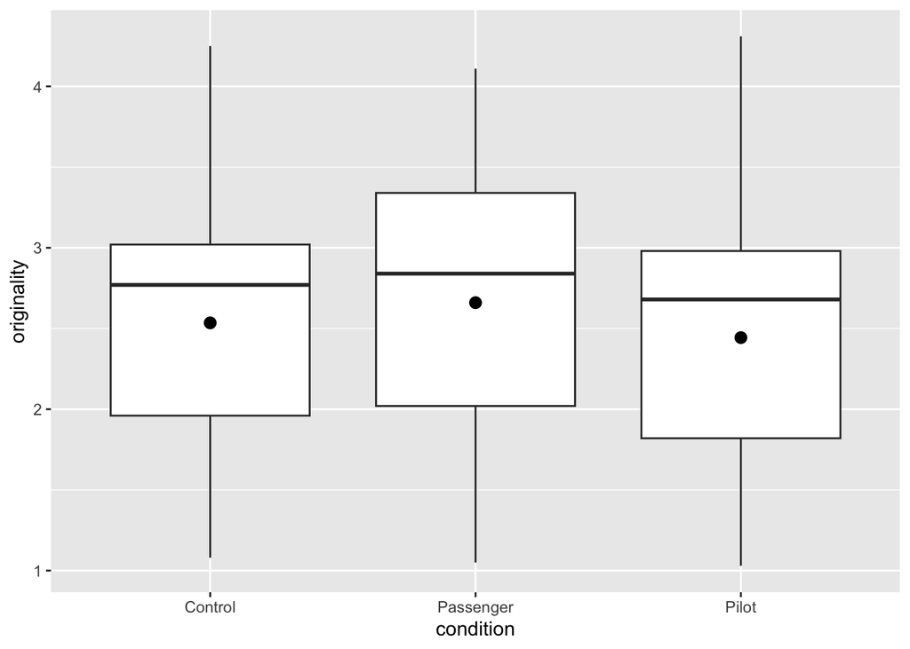

```r
originality <- read_csv("data/trial_data_scored.csv")
# Add a column with trial number
originality_trials <- originality %>%
  mutate(trial_num = str_extract(trial, "(?<=_)[^_]*$")) %>%
  relocate(trial_num, .after = "trial")

# Originality by condition
ggplot(originality, aes(x=condition, y=originality)) +
  geom_boxplot() +
  stat_summary(fun="mean")
```

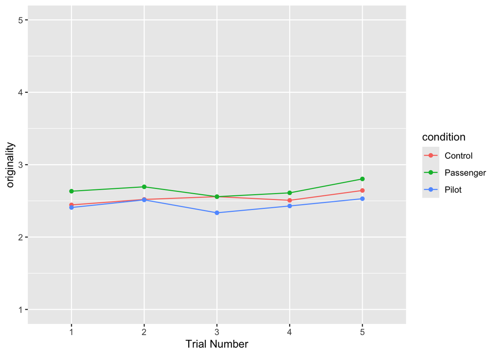

```r
# Plot originality over the course of the study
originality_trials %>%
  group_by(condition, trial_num) %>%
  summarize(originality = mean(originality)) %>%
  ggplot(aes(x=trial_num, y = originality, group=condition, color=condition)) +
  geom_line() +
  geom_point() +
  labs(x="Trial Number") +
  ylim(1,5)
```

In this small sample of N=15/condition, the Passenger condition had the most original responses (as scored by the model), followed by the Control condition, and then the Pilot condition.

## Homogeneity analysis using sentence embedding model

```r
options(digits=3)

# Group the uses by condition and object
trial_data %>%
  select(ResponseId, condition, object, use) %>%
  group_by(condition, object) %>%
  arrange(condition, object)
```

| ResponseId | condition | object | use |
| --- | --- | --- | --- |
| R_5xAXRcsLw4skwNj | Control | brick | door stop |
| R_5xAXRcsLw4skwNj | Control | brick | tofu press |
| R_5xAXRcsLw4skwNj | Control | brick | excersize weight |
| R_5xAXRcsLw4skwNj | Control | brick | planter |
| R_5xAXRcsLw4skwNj | Control | brick | book end |
| R_5KU53SUL5HPNOXu | Control | brick | paperweight |
| R_5KU53SUL5HPNOXu | Control | brick | step |
| R_5KU53SUL5HPNOXu | Control | brick | weapon |
| R_5KU53SUL5HPNOXu | Control | brick | doorstop |
| R_5KU53SUL5HPNOXu | Control | brick | decor |

[output cut: 665 more lines]

```r
# Use sentence transformers model in Python to analyze semantic similarity
semantic_similarities <- read_csv("data/semantic_similarities.csv")
semantic_similarities_summary <- read_csv("data/semantic_similarity_summary.csv")
semantic_similarities %>%
  group_by(condition) %>%
  summarize(mean_similarity = mean(similarity),
            sd_similarity = sd(similarity)) %>%
  arrange(desc(mean_similarity))
```

| condition | mean_similarity | sd_similarity |
| --- | --- | --- |
| Passenger | 0.218 | 0.169 |
| Pilot | 0.198 | 0.158 |
| Control | 0.181 | 0.141 |

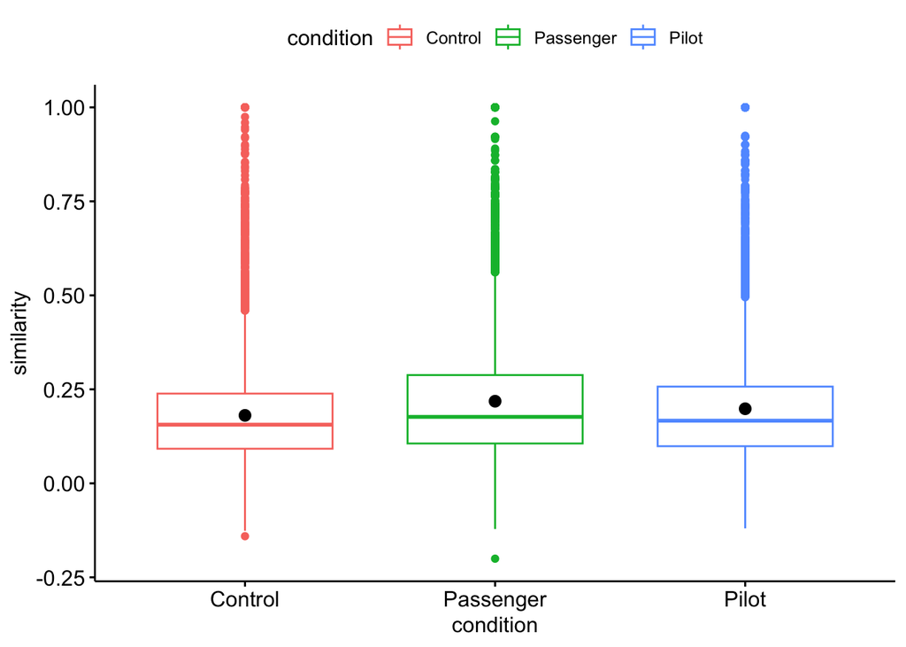

```r
ggboxplot(semantic_similarities, x="condition", y="similarity", color="condition") +
  stat_summary(fun="mean")
```

The Passenger condition had the greatest semantic similarity among ideas, followed by the Pilot condition, and then Control condition.

## Crowdsourced evaluations of creativity

The next step will be to have another set of crowdworkers evaluate the creativity of the pilot participants’ ideas in terms of overall creativity, originality, and usefulness.

```r
# Prepare idea submissions dataset for evaluation by another group of crowdworkers
# The data needs to be in long format, where each row represents a single idea for a single object

# In case you want to view wide
idea_submissions_wide <- trial_data %>%
  mutate(trial = str_extract(trial, "([A-Za-z0-9]+)(_)([A-Za-z0-9]+)$")) %>%
  pivot_wider(id_cols = c("ResponseId", "condition", "process_open-ended"),
              names_from = "trial",
              values_from = "use")

idea_submissions_long <- trial_data %>%
  unite(col = "idea_id", ResponseId, trial, sep="-")


write_csv(idea_submissions_long, "data/idea_submissions.csv")

# Create separate csvs for frisbee, brick, and bubblewrap
frisbee_submissions <- idea_submissions_long %>%
  filter(object=="frisbee")

brick_submissions <- idea_submissions_long %>%
  filter(object=="brick")

bubble_submissions <- idea_submissions_long %>%
  filter(object=="bubblewrap")

# Save to csvs

write_csv(frisbee_submissions, "data/frisbee_submissions.csv")
write_csv(brick_submissions, "data/brick_submissions.csv")
write_csv(bubble_submissions, "data/bubble_submissions.csv")
```

## Analysis of crowdworkers’ subjective evaluations

N = 99 participants

```r
# Read in the crowdworker evaluations
# Each row represents a crowdworkers' responses. The data is super wide because each column represents a response to a single pilot study participant's idea
# First, wrangle the data so that the column format is similar to the pilot study data: frisbee_1, frisbee_2...bubble_5

crowdworkers <- read_csv("data/crowdworker_eval_2025.09.18.csv")
# Check which idea submitter is tied to which crowdworker
submitter_ids <- crowdworkers %>%
  slice_head(n=1) %>%
  pivot_longer(cols = 14:2038,
               names_to = "participant_trial",
               values_to = "submitter_id") %>%
  select(participant_trial, submitter_id) %>%
  mutate(submitter_id = str_extract(submitter_id, "R_[A-Za-z0-9]+")) %>%
  separate(participant_trial,
           into = c("person_id", "trial"),
           extra = "merge") %>%
    separate(col = trial,
           into = c("metric", "trial"),
           sep = "_",
           extra = "merge") %>%
  mutate(metric = case_when(metric == "c" ~ "creativity",
                            metric == "o" ~ "originality",
                            metric == "u" ~ "usefulness")) %>%
  distinct(person_id, submitter_id)


crowdworker_eval <- crowdworkers %>%
  filter(DistributionChannel=="anonymous")

crowdworker_passed_attn_check <- crowdworker_eval %>%
  filter(attn_check == "4" & attn_check_4_TEXT == "8")
```

```r
# Ensure there is a column for the ID of the pilot participant that the submitted idea came from
crowdworker_eval_long <- crowdworker_passed_attn_check %>%
  pivot_longer(cols = 14:2038,
               names_to = "participant_trial",
               values_to = "rating") %>%
  drop_na(rating) %>%
  separate(col = participant_trial,
           into = c("person_id", "trial"),
           sep = "_",
           extra = "merge") %>%
  mutate(rating = as.numeric(rating)) %>%
  separate(col = trial,
           into = c("metric", "trial"),
           sep = "_",
           extra = "merge") %>%
  mutate(metric = case_when(metric == "c" ~ "creativity",
                            metric == "o" ~ "originality",
                            metric == "u" ~ "usefulness")) %>%
  unite(col="participant_rating_id", ResponseId, metric, trial, remove = FALSE) %>%
  mutate(trial_id = str_remove(participant_rating_id, "_creativity|_originality|_usefulness")) %>%
  pivot_wider(id_cols=c(trial_id, person_id),
              names_from = "metric",
              values_from = "rating")


crowdworkers_submitters <- left_join(crowdworker_eval_long, submitter_ids, by = "person_id") %>%
  extract(trial_id,
          into = c("crowdworker_id", "trial"),
          regex = "(R_[A-Za-z0-9]+)_(.*)")
```

```r
# Merge with trial data from the pilot
# participantID refers to the CloudResearch ID of the idea submitter

trial_data_renamed <- trial_data %>%
  rename(submitter_id = "ResponseId") %>%
  mutate(trial = str_remove(trial, "^[^_]*_")) %>%
  select(submitter_id, condition, trial, object, use, participantId)

crowdworkers_submitters_ideas <- full_join(crowdworkers_submitters, trial_data_renamed, by=c("submitter_id", "trial"))

# Descriptives of overall creativity, originality, and usefulness by condition
crowdworkers_submitters_ideas %>%
  group_by(condition) %>%
  get_summary_stats(c(creativity, originality, usefulness),
                    type="mean_sd") %>%
  arrange(variable)
```

| condition | variable | n | mean | sd |
| --- | --- | --- | --- | --- |
| Control | creativity | 450 | 2.49 | 1.14 |
| Passenger | creativity | 570 | 2.83 | 1.17 |
| Pilot | creativity | 465 | 2.78 | 1.25 |
| Control | originality | 450 | 2.46 | 1.25 |
| Passenger | originality | 570 | 2.73 | 1.27 |
| Pilot | originality | 465 | 2.73 | 1.38 |
| Control | usefulness | 450 | 3.00 | 1.31 |
| Passenger | usefulness | 570 | 3.11 | 1.25 |
| Pilot | usefulness | 465 | 3.15 | 1.29 |